# Datos de Carpobrotus edulis en NaturalistaUY

Author

Florencia Grattarola

Published

April 28, 2023

## Descarga de datos de *Carpobrotus edulis*

Para descargar datos de NaturalistaUY usé la [API de iNaturalist](https://api.inaturalist.org/v1/docs/). Los datos se descargan considerando:

- Uruguay como localización: `place_id=7259`
- Carpobrotus edulis como taxón: `taxon_id=49322`
- Registros con Grado de Investigación: `quality_grade=research`

```r
library(httr)
library(jsonlite)
library(tidyverse)

getCarpobrotusObservations <- function(place_id, taxon_id, quality_grade){

  call <- str_glue('https://api.inaturalist.org/v1/observations?place_id={place_id}&taxon_id={taxon_id}&per_page=200&quality_grade={quality_grade}')

  get_json_call <- GET(url = call) %>%
      content(as = "text") %>% fromJSON(flatten = TRUE)

  if (!is.null(get_json_call)) {
      results <- as_tibble(get_json_call$results)
      results <- results %>%
      select(taxon.name, taxon.rank, identifications_count, observed_on,
                  geojson.coordinates, positional_accuracy,
                  user.login, user.id, user.name, user.observations_count,
                  user.identifications_count, user.activity_count,
                  license_code, num_identification_agreements, uri) %>%
      unnest_wider(geojson.coordinates, names_sep = "_") %>%
      rename(longitude=geojson.coordinates_1, latitude=geojson.coordinates_2)
    }
  return(results)
}

datos_carpobrotus <- getCarpobrotusObservations(place_id=7259,
                                                taxon_id=49322,
                                      quality_grade='research')
```

## Análisis preliminar

Este es un resumen inicial de los datos disponibles al día de hoy 2023-04-28.

### Mapas

Para descargar los mapas usé el paquete `geouy`, haciendo: `geouy::load_geouy('Dptos')`. Guardé este objeto para evitar descargarlo nuevamente. El archivo tiene como CRS `EPSG:32721`.

```r
library(lubridate)
library(geonames)
options(geonamesUsername="biodiversidata") # A (free) username is required and rate limits exist
library(tmap)
tmap_mode("view")
library(sf)
sf::sf_use_s2(FALSE)
# options
options(scipen = 999)

uruguay <- readRDS('../data/Uruguay.rds')
deptos_costeros <- c('MONTEVIDEO','MALDONADO','CANELONES', 'ROCHA')
costa_uruguay <- uruguay %>% filter(nombre %in% deptos_costeros)

getStateProvince <- function(lat, lng){
  subdivision <- try(GNcountrySubdivision(lat, lng, radius = "1", maxRows = 1), silent = TRUE)
  Sys.sleep(1.0)
  if(class(subdivision)=='try-error'){
    subdivision$adminName1 <- NA
  }
  else if (length(subdivision$adminName1)==0){
    subdivision$adminName1 <- NA
  }
  return(subdivision$adminName1)
}

datos_carpobrotus<- datos_carpobrotus %>%
  mutate(stateProvince=map2_chr(latitude, longitude, getStateProvince)) %>%
  mutate(observed_on=as_date(observed_on)) %>%
  mutate(season=lubridate::quarter(observed_on)) %>%
  mutate(season=ifelse(season==1, 'verano',
                       ifelse(season==2, 'otoño',
                              ifelse(season==3, 'invierno', 'primavera'))))

saveRDS(datos_carpobrotus, '../data/datos_carpobrotus.rds')
write_excel_csv(datos_carpobrotus, '../data/datos_carpobrotus.csv', na = '')

sf_carpobrotus <- datos_carpobrotus %>%
    st_as_sf(coords = c("longitude", "latitude")) %>%
    st_set_crs(4326) %>%
    st_transform(32721)

mapa.carpobrotus <- tm_graticules(alpha = 0.3) +
    tm_shape(costa_uruguay) +
    tm_fill(col='grey90') +
    tm_borders(col='grey60', alpha = 0.4) +
    tm_shape(sf_carpobrotus) +
    tm_dots(alpha = 0.4)

mapa.carpobrotus
```

[interactive chart not shown]

### Más Detalles

Un total de **77** usuaries llevan hechos **196** registros de *Carpobrotus edulis*. El primer registro es de 2008-03-16 y el último es de 2023-04-25.

- Datos por departamento

```r
library(knitr)

datos_carpobrotus %>%
  group_by(stateProvince) %>%
  count() %>%  rename(Departamento=stateProvince,
                                     `Cantidad de registros`=n) %>%
  kable()
```

| Departamento | Cantidad de registros |
| --- | --- |
| Canelones | 43 |
| Maldonado | 97 |
| Montevideo | 4 |
| Montevideo Department | 5 |
| Rocha | 1 |
| Rocha Department | 46 |

- Estacionalidad

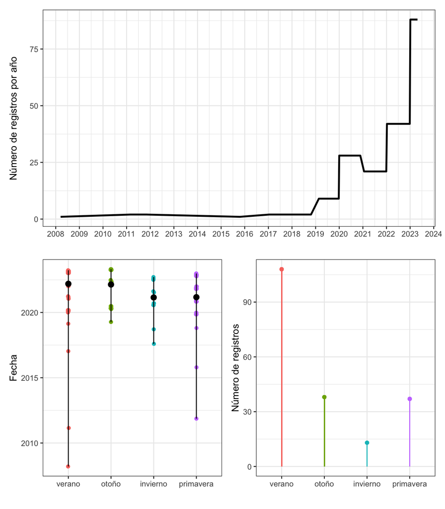

```r
library(patchwork)

timeline.plot <- datos_carpobrotus %>%
    add_count(taxon.name, year=year(observed_on),
              name='records_per_year') %>%
    ggplot(., aes(x=observed_on, y=records_per_year)) +
    geom_line(show.legend = FALSE, size=1) +
    scale_x_date(date_breaks = "1 year", date_labels = "%Y") +
    theme_bw()+
    labs(x='', y= 'Número de registros por año')


season.year.plot <- datos_carpobrotus %>%
    add_count(taxon.name, season, name='records_per_season') %>%
    mutate(season=factor(season,
                         levels = c('verano', 'otoño', 'invierno', 'primavera'))) %>%
    ggplot(aes(x=season, y=observed_on)) +
    geom_jitter(aes(col = season), width = 0.01, show.legend = FALSE) +
    stat_summary(fun = mean, fun.min = min, fun.max = max) +
    theme_bw() +
    labs(x='', y= 'Fecha')

season.n.plot <- datos_carpobrotus %>%
    add_count(taxon.name, season, name='records_per_season') %>%
    mutate(season=factor(season,
                         levels = c('verano', 'otoño', 'invierno', 'primavera'))) %>%
    ggplot(aes(x=season, y=records_per_season)) +
    geom_segment(aes(x=season, xend=season, y=0,
                     yend=records_per_season, col=season), show.legend = FALSE) +
    geom_point(aes(col=season), show.legend = FALSE) +
    theme_bw() +
    labs(x='', y= 'Número de registros')

timeline.plot / (season.year.plot | season.n.plot)
```

## Descarga de todos los datos para Montevideo, Canelones, Maldonado y Rocha

En este caso usamos:

- Montevideo, Canelones, Maldonado y Rocha como localización: `place_id=12416`, `place_id=12410`, `place_id=12415`, `place_id=12420`
- Que no sean de organismos cultivados/captivos: `captive=false`
- Que tengan`geoprivacy=open`

La API sugiere mantener *60 requests per minute* (1 solicitud x 1 segundo), así que para descargar estos datos tenemos que generar una pausa en el código para no saturar a la API (`delay=1.0`). Además, vamos a dividir el resultado en 200 resultados por página (`per_page=200`).

**Problema**

De esta manera sólo podemos descargar hasta 10,000 observaciones. Tengo que buscarle la vuelta para controlar el `id_above` cuando se llega a 10 mil y hacer una nueva llamada con ese id. Ver [API Recommended Practices](https://www.naturalista.uy/pages/api+recommended+practices)

```r
getAllObservations <- function(place_id){

  total_results = NULL
  page = 1
  delay = 1.0
  results = tibble()

  while(is.null(total_results) || nrow(results) < total_results) {

    call_url <- str_glue('https://api.inaturalist.org/v1/observations?',
                         'place_id={place_id}',
                         '&captive=false&geoprivacy=open',
                         '&per_page=200&page={page}')
    get_json_call <- GET(url = call_url) %>%
      content(as = "text") %>% fromJSON(flatten = TRUE)

    if (!is.null(get_json_call)) {
      if (is.null(total_results)) {
        total_results = get_json_call$total_results
      }
      results_i <- as_tibble(get_json_call$results) %>%
        select(taxon.name, taxon.rank, identifications_count, observed_on,
               geojson.coordinates, positional_accuracy,
               user.login, user.id, user.name, user.observations_count,
               user.identifications_count, user.activity_count,
               license_code, num_identification_agreements) %>%
        unnest_wider(geojson.coordinates, names_sep = "_") %>%
        rename(longitude=geojson.coordinates_1, latitude=geojson.coordinates_2)
      results <- rbind(results, results_i)
      page <- page + 1
      Sys.sleep(delay)
    }
  }
  return(results)
}

# place_id
montevideo_place_id=12416
canelones_place_id=12410
maldonado_place_id=12415
rocha_place_id=12420

montevideoObservations <- getAllObservations(montevideo_place_id)
canelonesObservations <- getAllObservations(canelones_place_id)
maldonadoObservations <- getAllObservations(maldonado_place_id)
rochaObservations <- getAllObservations(rocha_place_id)

allObservations <- bind_rows(montevideoObservations,
                             canelonesObservations,
                             maldonadoObservations,
                             rochaObservations)

# saveRDS(allObservations, '../data/allObservations.rds')
```

Por ahora vamos a descargar los datos directamente de naturalista.uy/observations/export.

**Descarga de datos**

Hecha el 12 de marzo, 2023.

```r
allObservations <- read_csv('../data/observations-303864.csv', guess_max = 72000)

allObservations <- allObservations %>%
  filter(coordinates_obscured==FALSE & !is.na(taxon_species_name)) %>%
  select(kingdom=taxon_kingdom_name, phylum=taxon_phylum_name,
         class=taxon_class_name, order=taxon_order_name,
         family=taxon_family_name, genus=taxon_genus_name,
         species=taxon_species_name, scientific_name,
         quality_grade, observed_on, user_login, user_id,
         state_province=place_admin1_name,
         longitude, latitude)

allObservations_sf <- allObservations %>%
    st_as_sf(coords = c("longitude", "latitude")) %>%
    st_set_crs(4326) %>%
    st_transform(32721)
```

## Análisis espacial

- Creación de grillas para los cuatro departamentos de la costa (10x10km)

```r
costa_uruguay_grillas <- st_make_grid(st_union(costa_uruguay), 10000) %>%
  st_intersection(st_union(costa_uruguay)) %>%
  st_sf(gridID=1:length(.), geometry= .) %>%
  st_make_valid() %>% st_cast()
```

### Intersección de grillas con datos totales y para *Caprobrotus edulis*

```r
grillas_allObservations <- st_join(costa_uruguay_grillas,
                                   allObservations_sf) %>%
  group_by(gridID) %>%
  summarise(NR=ifelse(n_distinct(species, na.rm=T)!=0, n(), 0),
            SR=n_distinct(species, na.rm = T),
            spsList = paste(species, collapse = ';')) %>%
  st_cast()

grillas_carpobrotus <- st_join(costa_uruguay_grillas, sf_carpobrotus) %>%
  group_by(gridID) %>%
  summarise(NR=ifelse(n_distinct(taxon.name, na.rm=T)!=0, n(), 0)) %>%
  st_cast()
```

### Estimación del esfuerzo de muestreo por grilla

Usamos la función `get_gridsSlopes()` generada para análisis de Biodiversidata ([Grattarola et al. 2020](https://doi.org/10.1038/s41598-020-79074-8)).

**Más info sobre este análisis**

El código está disponible en GitHub: [Multiple forms of hotspots of tetrapod biodiversity and the challenges of open-access data scarcity](https://github.com/bienflorencia/Multiple-forms-of-hotspots-of-tetrapod-biodiversity/blob/22bf5de985ba25267efa64fd308574547437e566/R/04_identification_of_areas_of_ignorance.R).

> To identify the areas of ignorance we quantified the levels of inventory incompleteness for each group by using curvilinearity of smoothed species accumulation curves (SACs). This method assumes that SACs of poorly sampled grids tend towards a straight line, while those of better sampled ones have a higher degree of curvature. As a proxy for inventory incompleteness we calculated the degree of curvilinearity as the mean slope of the last 10% of SACs.

````r
# The function ```get_gridsSlopes``` finds a species accumulation curve (SAC) for each grid-cell using the method ‘exact’ of the function ```specaccum``` of the vegan package and then calculates the degree of curvilinearity as the mean slope of the last 10% of the curve.

library(vegan)
library(spaa)

get_gridsSlopes <- function(data_abundance){
  gridSlope <- data.frame(gridID=integer(), slope=numeric(), stringsAsFactors=FALSE)
  data_abundance <- as.data.frame(data_abundance)
  data_abundance$abundance <- as.integer(1)
  cells <- unique(data_abundance$gridID)
  splistT <- list()
  spaccum <- list()
  slope <- list()
  for (i in cells) {
    splist <- data_abundance[data_abundance$gridID == i,c(2:4)]
    splistT[[i]] = data2mat(splist)
    spaccum[[i]] = specaccum(splistT[[i]], method = "exact")
    slope[[i]] = (spaccum[[i]][[4]][length(spaccum[[i]][[4]])]-
                    spaccum[[i]][[4]][ceiling(length(spaccum[[i]][[4]])*0.9)])/
      (length(spaccum[[i]][[4]])- ceiling(length(spaccum[[i]][[4]])*0.9))
    gridSlope_i <- data.frame(gridID=i, slope=slope[[i]], stringsAsFactors=FALSE)
    gridSlope <- rbind(gridSlope, gridSlope_i)
  }
  gridSlope <- gridSlope %>% as_tibble() %>%
    mutate(slope=ifelse(is.nan(slope), NA, slope))
  return(gridSlope)
}

allObservations.SACs <- grillas_allObservations %>% as_tibble() %>%
    mutate(species=str_split(spsList, ';')) %>%
    unnest(species) %>%
    group_by(spsList) %>% mutate(sample = row_number()) %>%
    ungroup() %>%
    mutate(sample=ifelse(is.na(species), 0 , sample)) %>%
    select(gridID, sample, species)

allObservations.incompleteness <- get_gridsSlopes(allObservations.SACs)
````

Unión espacial de todas los datos por grilla: número de registros totales, número de especies totales, curva de incompleteness (esfuerzo de muestreo), y número de registros de *Carpobrotus edulis*.

```r
costa_uruguay.incompleteness <- left_join(grillas_allObservations,
          allObservations.incompleteness) %>%
  left_join(., grillas_carpobrotus %>%
              rename(carpobrotus=NR) %>%
              st_drop_geometry())
```

### Figuras

- Mapas

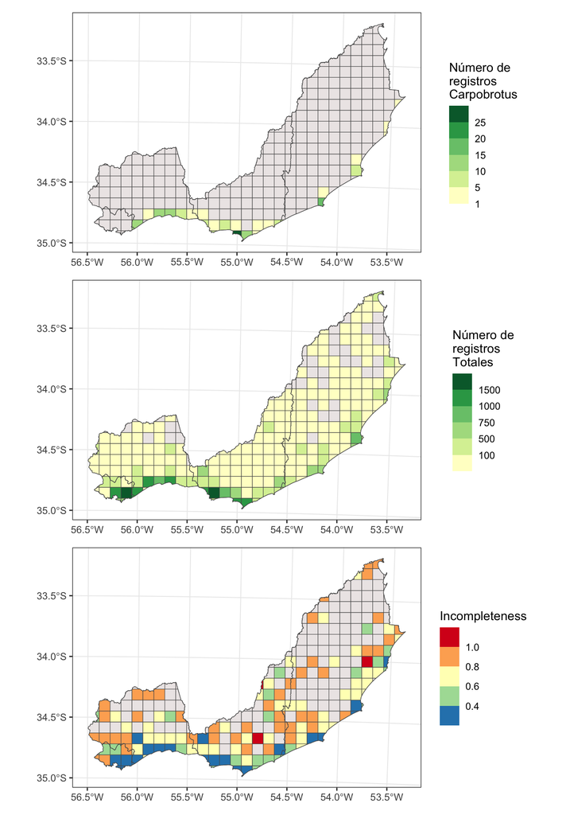

```r
registros.carpobrotus <- ggplot() +
    geom_sf(data=costa_uruguay.incompleteness %>%
                mutate(carpobrotus=ifelse(carpobrotus==0, NA, carpobrotus)),
            aes(fill=carpobrotus)) +
    scale_fill_fermenter(palette ='YlGn', direction = 1,
                         breaks = c(0,1, 5,10,15,20,25),
                         na.value="#ede8e8") +
    geom_sf(data=costa_uruguay, fill=NA) +
    labs(fill='Número de\nregistros\nCarpobrotus') +
    theme_bw()

n.registros <- ggplot() +
    geom_sf(data=costa_uruguay.incompleteness %>%
              mutate(NR=ifelse(NR==0, NA, NR)),
            aes(fill=NR)) +
    scale_fill_fermenter(palette ='YlGn',
                         direction = 1,
                         breaks = c(0, 100, 500, 750, 1000, 1500),
                         na.value="#ede8e8") +
    geom_sf(data=costa_uruguay, fill=NA) +
    labs(fill='Número de\nregistros\nTotales') +
    theme_bw()

sac <- ggplot() +
    geom_sf(data=costa_uruguay.incompleteness, aes(fill=slope)) +
    scale_fill_fermenter(palette ='Spectral', na.value="#ede8e8") +
    geom_sf(data=costa_uruguay, fill=NA) +
    labs(fill='Incompleteness') +
    theme_bw()

registros.carpobrotus/ n.registros / sac
```

- Correlaciones

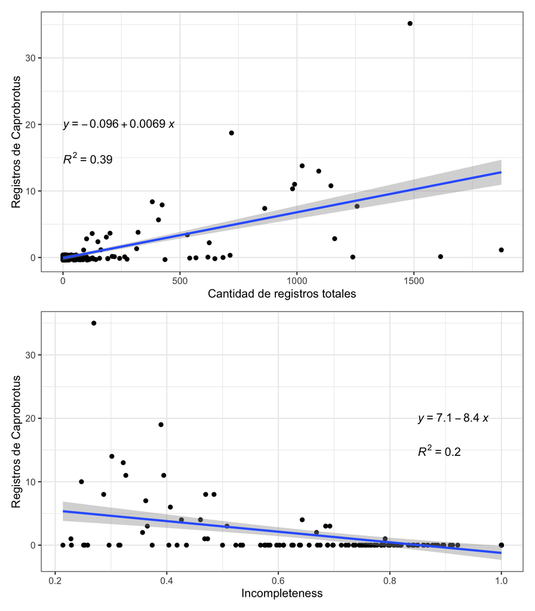

```r
library(ggpubr)

tabla.final <- costa_uruguay.incompleteness %>%
    st_drop_geometry() %>%
    #mutate(slope=ifelse(is.na(slope), 0, slope)) %>%
    select(grilla=gridID, NR, SR, carpobrotus, slope)

lm.nr <- summary(lm(carpobrotus ~ NR, data=tabla.final))

nr.caprobrotus <- ggplot(tabla.final, aes(x=NR, y=carpobrotus)) +
    geom_jitter() +
    geom_smooth(method = 'lm') +
    stat_regline_equation(label.y = 20, aes(label = ..eq.label..)) +
    stat_regline_equation(label.y = 15, aes(label = ..rr.label..)) +
    labs(x='Cantidad de registros totales', y='Registros de Caprobrotus') +
    theme_bw()

lm.sac <- summary(lm(carpobrotus ~ slope, data=tabla.final))

incompleteness.caprobrotus <- ggplot(tabla.final,
       aes(x=slope, y=carpobrotus)) +
    geom_point() + geom_smooth(method = 'lm') +
    stat_regline_equation(label.y = 20, label.x = 0.85, aes(label = ..eq.label..)) +
    stat_regline_equation(label.y = 15, label.x = 0.85, aes(label = ..rr.label..)) +
    labs(x='Incompleteness', y='Registros de Caprobrotus') +
    theme_bw()

nr.caprobrotus / incompleteness.caprobrotus
```

### Tabla

La tabla final de datos con información por grilla:  
- **Núm de registros totales**: cantidad de registros en NaturalistaUY de cualquier especie  
- **Núm de especies totales**: cantidad de especies en NaturalistaUY  
- **Núm de registros Carpobrotus**: cantidad de registros en NaturalistaUY de *Carpobrotus edulis*  
- **Incompleteness**: medida de esfuerzo de muestreo (valores cercanos a 0 indican grillas completas)

```r
tabla.final %>%
  select(`Núm de registros totales`=NR,
         `Núm de especies`=SR,
         `Núm de registros Carpobrotus`=carpobrotus,
         Incompleteness=slope) %>%
  kable(digits = 3)
```

| Núm de registros totales | Núm de especies | Núm de registros Carpobrotus | Incompleteness |
| --- | --- | --- | --- |
| 0 | 0 | 0 | NA |
| 649 | 269 | 0 | 0.297 |
| 568 | 306 | 0 | 0.374 |
| 382 | 253 | 8 | 0.485 |
| 1483 | 676 | 35 | 0.269 |
| 1093 | 551 | 13 | 0.322 |
| 315 | 212 | 1 | 0.473 |
| 74 | 67 | 0 | 0.819 |
| 81 | 72 | 0 | 0.820 |
| 1239 | 549 | 0 | 0.258 |
| 1614 | 714 | 0 | 0.253 |
| 1145 | 675 | 11 | 0.395 |
| 67 | 58 | 0 | 0.754 |
| 1257 | 610 | 8 | 0.287 |
| 1874 | 802 | 1 | 0.228 |
| 862 | 504 | 7 | 0.362 |
| 531 | 367 | 3 | 0.508 |
| 88 | 72 | 0 | 0.670 |
| 162 | 105 | 1 | 0.468 |
| 321 | 194 | 4 | 0.426 |
| 408 | 240 | 6 | 0.407 |
| 1 | 1 | 0 | NA |
| 436 | 250 | 0 | 0.404 |
| 191 | 139 | 0 | 0.575 |
| 37 | 35 | 0 | 0.895 |
| 130 | 110 | 0 | 0.713 |
| 1161 | 650 | 3 | 0.365 |
| 990 | 488 | 11 | 0.327 |
| 1022 | 498 | 14 | 0.302 |
| 424 | 274 | 8 | 0.470 |

[output cut: 231 more lines]